# Second R Homework

Himesh Buch

### Getting started.

Be sure to change the author name above to your own. When you are ready to submit the homework, submit only this file and not the html file. Notice this file ends in “Rmd”, short for “R Markdown.”

First, you will need to load the necessary packages. The last package, `lme4`, is included because it has the data we need.

We will look at the `sleepstudy` data frame. You can learn more about it with `?sleepstudy`, but the basics are that 18 subjects were allowed only 3 hours of sleep a night. Their reaction times were measured each day for 10 days.

First a summary of the data frame, then a quick look at all of the data at once, followed by separate plots for each subject.

```r
summary(sleepstudy)
```

```
    Reaction          Days        Subject
 Min.   :194.3   Min.   :0.0   308    : 10
 1st Qu.:255.4   1st Qu.:2.0   309    : 10
 Median :288.7   Median :4.5   310    : 10
 Mean   :298.5   Mean   :4.5   330    : 10
 3rd Qu.:336.8   3rd Qu.:7.0   331    : 10
 Max.   :466.4   Max.   :9.0   332    : 10
                               (Other):120
```

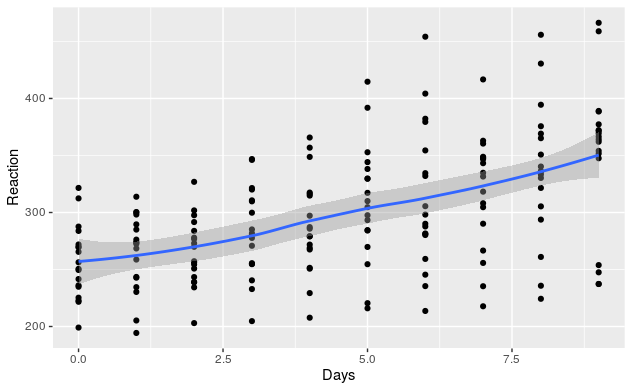

```r
sleepstudy %>%
  ggplot(aes(x = Days, y = Reaction)) +
  geom_point() +
  geom_smooth()
```

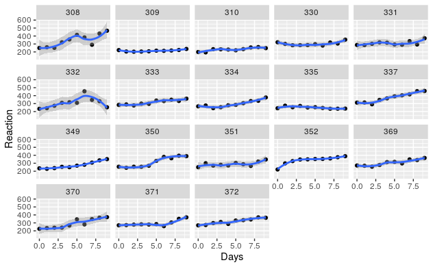

```r
sleepstudy %>%
  ggplot(aes(x = Days, y = Reaction)) +
  geom_point() +
  geom_smooth() +
  facet_wrap(~ Subject)
```

### Exercise 1

```r
sleep1 <- stan_glm(Days ~ Reaction,  data = sleepstudy)
```

Take a look at the posterior predictive check before we go on.

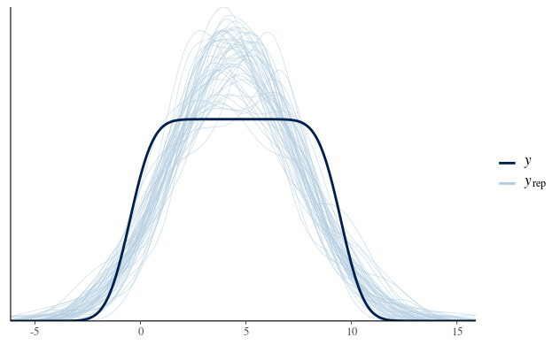

```r
pp_check(sleep1)
```

It fits okay, but clearly there are some issues.